# Coursera Practical Machine Learning Project

zedleb

8 October 2016

## Synopsis

The goal of this project is to use machine learning **to predict the manner in which a certain exercise was performed** using data collected in the following research:

*Qualitative Activity Recognition of Weight Lifting Exercises*

*Six young health participants were asked to perform one set of 10 repetitions of the Unilateral Dumbbell Biceps Curl in five different fashions: exactly according to the specification (Class A), throwing the elbows to the front (Class B), lifting the dumbbell only halfway (Class C), lowering the dumbbell only halfway (Class D) and throwing the hips to the front (Class E). Class A corresponds to the specified execution of the exercise, while the other 4 classes correspond to common mistakes.*

[Velloso, E.; Bulling, A.; Gellersen, H.; Ugulino, W.; Fuks, H. Qualitative Activity Recognition of Weight Lifting Exercises. Proceedings of 4th International Conference in Cooperation with SIGCHI (Augmented Human ’13) . Stuttgart, Germany: ACM SIGCHI, 2013](http://groupware.les.inf.puc-rio.br/har#weight_lifting_exercises)

### Componenents of a Predictor

Following J Leek’s suggested [model](https://www.coursera.org/learn/practical-machine-learning/lecture/116Tb/what-is-prediction) for building a predictor we aim to:  
1. Start with a specific and well-defined **question**  
2. Gather the best **input data** to use for prediction  
3. Decide or compute **features** from the input data  
4. Apply machine learning **algorithms** (in training set)  
5. Estimate the **parameters** of the algorithms (in training set)  
6. Apply and **evaluate** these parameters (in test set)

## 1. The Question

The question we are seeking to answer is *by processing and applying algorithms to the collected observations of various accelerometers - can the quality (class A-E) of the performance of the weight-lifting exercise be predicted?*

## 2. Getting and cleaning the data

The training data for this project are available here:  
https://d396qusza40orc.cloudfront.net/predmachlearn/pml-training.csv

The test data are available here:  
https://d396qusza40orc.cloudfront.net/predmachlearn/pml-testing.csv

The predictor we are interested in is the “classe” variable in the training set.

```r
# URLs of the training and testing data
  url.train  <- "https://d396qusza40orc.cloudfront.net/predmachlearn/pml-training.csv"
  url.test   <-  "https://d396qusza40orc.cloudfront.net/predmachlearn/pml-testing.csv"
  f.train  <-  "./data/pml-training.csv"
  f.test   <-  "./data/pml-testing.csv"
# if directory does not exist, create new
  if (!file.exists("./data")) {
    dir.create("./data")
  }
# if files does not exist, download the files
  if (!file.exists(f.train)) {
    download(url.train, destfile=f.train)
  }
  if (!file.exists(f.test)) {
    download(url.test, destfile=f.test)
  }
# load the CSV files and glimpse the data
  rawTrain  <-  read.csv(f.train, na.strings = c("NA", ""))
  rawTest   <-  read.csv(f.test, na.strings = c("NA", ""))
  dim(rawTrain)
```

```
[1] 19622   160
```

```r
  dim(rawTest)
```

```
[1]  20 160
```

```r
# check to see that all column names are identical
  all.equal.character(colnames(rawTrain), colnames(rawTest))
```

```
[1] "1 string mismatch"
```

```r
  chk.cols <- colnames(rawTrain) == colnames(rawTest)
  match(FALSE, chk.cols)
```

```
[1] 160
```

```r
  c(colnames(rawTrain[160]), colnames(rawTest[160]))
```

```
[1] "classe"     "problem_id"
```

We identify that the two sets of data contain identical column names except the final variable in each case (in the training set it is our predictor) and in the test set it is where our prediction will be logged.

Run a check to see how many observations in the training set are not complete.

```r
  ok <- complete.cases(rawTrain)
  sum(!ok) # how many are not "ok" ?
```

```
[1] 19216
```

```r
  c1Train <- rawTrain[, colSums(is.na(rawTrain)) == 0]
  c1Test  <- rawTest[, colSums(is.na(rawTest)) == 0]

  ok <- complete.cases(c1Train)
  sum(!ok) # how many are not "ok" ?
```

```
[1] 0
```

## 3 Deciding on Features

We want to identify the features that best describe the data under examination. From the research paper we identify that the readings were taken from sensors in the users’ glove, armband, lumbar belt and dumbbell. The measurements were recorded for each sensor on the roll, pitch and yaw, as well as the raw accelerometer, gyroscope and magnetometer readings. These are the variables we wish to keep and run through our algorithms. We can safely dispose of the first seven variables which have little bearing on the outcome.

```r
c2Train <- c1Train[,8:length(colnames(c1Train))]
c2Test  <- c1Test[, 8:length(colnames(c1Test))]
validSet <-c2Test; rm(c2Test) # just a rename for sake of consistency later
```

This takes the number of variables down to 53 in both datasets.

## 4. Applying prediction algorithms in Training

Max Kuhn describes  
* Training Set: these data are used to estimate model parameters and to pick the values of the complexity parameter(s) for the model.  
* Test Set (aka validation set): these data can be used to get an independent assessment of model efficacy.  
We’ll keep our rather small `test` set to use as our ‘validation’ set - this is the sample where the final prediction will be performed.  
However, as we have a relatively large ‘train’ set, we will create data partitions (as a ‘train’ and ‘test’ set) to build and evaluate the model we decide upon. This requires us to split up `train` - we will set seed for the purposes of reproducibility.

```r
set.seed(777)
inTrain  <- createDataPartition(y=c2Train$classe, p=3/4, list=FALSE)
trainSet <- c2Train[inTrain, ]
testSet  <- c2Train[-inTrain, ]
```

We now have a 25/75 split of the original data set into:

- `testSet` with 4904 observations
- `trainSet` with 14718 observations

We will use cross-validation in `trainSet` to improve the model and `testSet` will be used for our out-of-sample error rate.

### Classification Tree prediction

*A classification tree searches through each predictor to find a value of a single variable that best splits the data into two groups. Typically, the best split minimizes impurity of the outcome in the resulting data subsets.* (Kuhn, 2013)

Here we include a 5-fold cross-validation.

```r
set.seed(777)
control.CT <- trainControl(method = "cv", number = 5)
mdl.CT <- train(classe ~ ., data = trainSet, method = "rpart", trControl = control.CT)
print(mdl.CT, digits = 4)
```

```
CART

14718 samples
   52 predictor
    5 classes: 'A', 'B', 'C', 'D', 'E'

No pre-processing
Resampling: Cross-Validated (5 fold)
Summary of sample sizes: 11776, 11774, 11775, 11774, 11773
Resampling results across tuning parameters:

  cp       Accuracy  Kappa
  0.03522  0.5054    0.35444
  0.06101  0.4412    0.25121
  0.11535  0.3324    0.07311

Accuracy was used to select the optimal model using  the largest value.
The final value used for the model was cp = 0.03522.
```

[figure not shown]

```r
fancyRpartPlot(mdl.CT$finalModel)
```

### Random Forests prediction

Our second choice for building a model is Random Forest. Setting the same seed and using the same number of folds for cross-validation.

```r
set.seed(777)
control.RF <- trainControl(method = "cv", number = 5)
mdl.RF <- train(classe ~ ., data = trainSet, method = "rf", trControl = control.RF, ntree=250)
print(mdl.RF, digits = 4)
```

```
Random Forest

14718 samples
   52 predictor
    5 classes: 'A', 'B', 'C', 'D', 'E'

No pre-processing
Resampling: Cross-Validated (5 fold)
Summary of sample sizes: 11776, 11774, 11775, 11774, 11773
Resampling results across tuning parameters:

  mtry  Accuracy  Kappa
   2    0.9931    0.9912
  27    0.9913    0.9890
  52    0.9851    0.9812

Accuracy was used to select the optimal model using  the largest value.
The final value used for the model was mtry = 2.
```

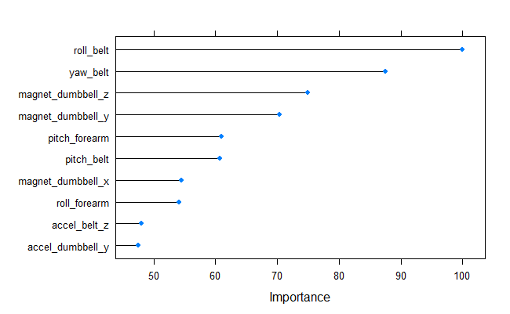

```r
plot(varImp(mdl.RF), top = 10)
```

```r
varImp(mdl.RF)
```

```
rf variable importance

  only 20 most important variables shown (out of 52)

                  Overall
roll_belt          100.00
yaw_belt            87.50
magnet_dumbbell_z   74.89
magnet_dumbbell_y   70.32
pitch_forearm       61.00
pitch_belt          60.70
magnet_dumbbell_x   54.47
roll_forearm        54.09
accel_belt_z        48.01
accel_dumbbell_y    47.45
magnet_belt_z       45.64
magnet_belt_y       42.90
roll_dumbbell       42.16
roll_arm            37.10
accel_forearm_x     35.65
accel_dumbbell_z    35.56
yaw_dumbbell        31.97
accel_dumbbell_x    31.10
magnet_arm_y        31.06
gyros_dumbbell_y    31.04
```

The variable recording `roll_belt` measurements features in both classification tree and random forest plots as clearly the most influential measurement in deciding class quality.

## 5. Estimate the parameters of the algorithms in Training

```r
predict.CT <- predict(mdl.CT, testSet)
Accuracy.CT <-confusionMatrix(predict.CT, testSet$classe)
Acc.rnd <- round(Accuracy.CT$byClass[3],3)
print(Accuracy.CT)
```

```
Confusion Matrix and Statistics

          Reference
Prediction    A    B    C    D    E
         A 1272  436  403  358  135
         B   23  295   26  150  127
         C   96  218  426  296  233
         D    0    0    0    0    0
         E    4    0    0    0  406

Overall Statistics

               Accuracy : 0.4892
                 95% CI : (0.4751, 0.5033)
    No Information Rate : 0.2845
    P-Value [Acc > NIR] : < 2.2e-16

                  Kappa : 0.3314
 Mcnemar's Test P-Value : NA

Statistics by Class:

                     Class: A Class: B Class: C Class: D Class: E
Sensitivity            0.9118  0.31085  0.49825   0.0000  0.45061
Specificity            0.6204  0.91757  0.79180   1.0000  0.99900
Pos Pred Value         0.4885  0.47504  0.33570      NaN  0.99024
Neg Pred Value         0.9465  0.84730  0.88198   0.8361  0.88985
Prevalence             0.2845  0.19352  0.17435   0.1639  0.18373
Detection Rate         0.2594  0.06015  0.08687   0.0000  0.08279
Detection Prevalence   0.5310  0.12663  0.25877   0.0000  0.08361
Balanced Accuracy      0.7661  0.61421  0.64502   0.5000  0.72481
```

```r
predict.RF <- predict(mdl.RF, testSet)
Accuracy.RF <-confusionMatrix(predict.RF, testSet$classe)
Acc.rnd.RF <- round(Accuracy.RF$byClass[3],3)
print(Accuracy.RF)
```

```
Confusion Matrix and Statistics

          Reference
Prediction    A    B    C    D    E
         A 1392    6    0    0    0
         B    0  942    7    0    0
         C    3    1  848   19    0
         D    0    0    0  785    1
         E    0    0    0    0  900

Overall Statistics

               Accuracy : 0.9925
                 95% CI : (0.9896, 0.9947)
    No Information Rate : 0.2845
    P-Value [Acc > NIR] : < 2.2e-16

                  Kappa : 0.9905
 Mcnemar's Test P-Value : NA

Statistics by Class:

                     Class: A Class: B Class: C Class: D Class: E
Sensitivity            0.9978   0.9926   0.9918   0.9764   0.9989
Specificity            0.9983   0.9982   0.9943   0.9998   1.0000
Pos Pred Value         0.9957   0.9926   0.9736   0.9987   1.0000
Neg Pred Value         0.9991   0.9982   0.9983   0.9954   0.9998
Prevalence             0.2845   0.1935   0.1743   0.1639   0.1837
Detection Rate         0.2838   0.1921   0.1729   0.1601   0.1835
Detection Prevalence   0.2851   0.1935   0.1776   0.1603   0.1835
Balanced Accuracy      0.9981   0.9954   0.9931   0.9881   0.9994
```

Our accuracy with Random Forest is 0.992 leading to a better out-of-sample rate of 0.008.

## 6. Apply and evaluate in the validation (test) set

Having selected the random forest model as our best predictor we now apply the model to our as yet untouched validation set. These are the predicted classes for the next twenty repetitions.

```r
predValidation <- predict(mdl.RF, validSet)
resultsValidation <- data.frame(
  problem_id=validSet$problem_id,
  predicted=predValidation
)
print(resultsValidation)
```

| problem_id | predicted |
| --- | --- |
| 1 | B |
| 2 | A |
| 3 | B |
| 4 | A |
| 5 | A |
| 6 | E |
| 7 | D |
| 8 | B |
| 9 | A |
| 10 | A |

[output cut: 10 more lines]

## References

Kuhn, M (2013) [*Predictive Modeling with R and the caret Package*](https://www.r-project.org/nosvn/conferences/useR-2013/Tutorials/kuhn/user_caret_2up.pdf) viewed 2016/09/30